# Lab 3 - BINF 6310

Erin Tsai

### Problem 1

##### 1. You walk into the “occasionally dishonest casino” with prior probabilities and likelihoods set to the values in slides 21-25 of lecture #4 (a “loaded” die has a 10% chance of getting a 1-5 and a 50% chance of getting a 6, but 99% of the dice are fair).

```r
likely_givenLoaded <- c( 0.1,0.1,0.1,0.1,0.1,0.5)
likely_givenNotLoaded<- c(1/6,1/6,1/6,1/6,1/6,1/6)
prob_ofLoaded <-  c(0.01,0.99)
```

##### You pick up one die and with it roll:

```r
data<-c(2,3,2,6,3,5,6,2,6,6,2,6,6,2,3,6,6,6,5,6,6,5,6,6,6,6,6,4,6,3,3,3,6,6,5,6,6)
data
```

```
##  [1] 2 3 2 6 3 5 6 2 6 6 2 6 6 2 3 6 6 6 5 6 6 5 6 6 6 6 6 4 6 3 3 3 6 6 5 6 6
```

##### Make a graph of the posterior probability that you have picked up a loaded die as a function of the number of times you have rolled the die. (Show your code.)

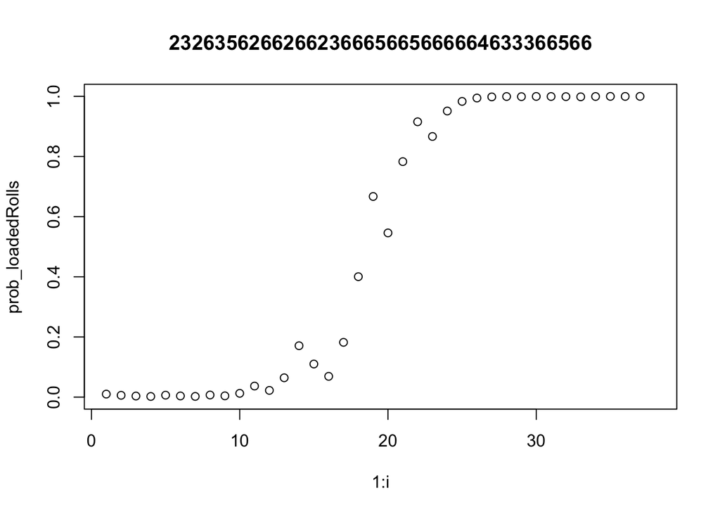

```r
prob_loadedRolls <- vector();
titleStr <- ""
for( i in 1:length(data))
{
  prob_loadedRolls[i] <- prob_ofLoaded[1];

  denom <- prob_ofLoaded[1] * likely_givenLoaded[data[i]] + prob_ofLoaded[2] * likely_givenNotLoaded[data[i]];
  prob_ofLoaded[1] <- prob_ofLoaded[1] * likely_givenLoaded[data[i]] / denom;
  prob_ofLoaded[2] = prob_ofLoaded[2] * likely_givenNotLoaded[data[i]] / denom

  titleStr <- paste(titleStr,data[i],sep="")
}
plot(1:i,prob_loadedRolls, main = titleStr,ylim=c(0,1),xlim=c(1,length(data)+1))
```

##### 2. How many times on average would you need to roll a loaded die to be 99.999% sure that it was loaded? (Show your work.)

```r
number_ofRolls <- vector();

for (i in 1:50){
  c <- 0
  prob_ofLoaded <-  c(0.01,0.99)
  while (TRUE){
    x <- sample(c(1:6),size=1,replace = TRUE,prob = c(0.1,0.1,0.1,0.1,0.1,0.5));

    denom <- prob_ofLoaded[1] * likely_givenLoaded[x] + prob_ofLoaded[2] * likely_givenNotLoaded[x];
    prob_ofLoaded[1] = prob_ofLoaded[1] * likely_givenLoaded[x] / denom;
    prob_ofLoaded[2] = prob_ofLoaded[2] * likely_givenNotLoaded[x] / denom;
    c <- c+1

    if (prob_ofLoaded[1] >= 0.99999){
      number_ofRolls[i] <- c
      break
    }
  }
}

mean_rolls = mean(number_ofRolls)
```

- The average number of rolls required is **58.24**.

### Problem 2

##### You are consulting for a hospital. They have a diagnostic test for a disease with a known background prevalence of 0.1%.

##### The test has the following properties:

##### p(positive result | person has disease) = 0.91

##### p(negative result | person does not have disease) = 0.84

##### The cost of running the test one time is $1. The test can be repeated for each patient and the results of the test are independent of one another allowing for Bayesian updates. The test always yields a positive or negative result.

##### The requirement of the hospital is that the test is repeated for each patient until a Bayesian posterior of at least 0.99999 is reached.

##### 1. Run simulations for a patient with the disease. About how many times on average must the test be repeated to achieve the hospital’s requirements?

```r
prob_hasDisease = c(0.001, 0.999)
pos_testDisease = c(0.91, 0.09)
pos_testNoDisease = c(0.16, 0.84)
num_tests_pos_res = 0

for(i in 1:10000){
  res = ((pos_testDisease[1] ** i) * prob_hasDisease[1])/(((pos_testDisease[1] ** i) * prob_hasDisease[1]) + ((pos_testDisease[2] ** i) * prob_hasDisease[2]))

  if(res > 0.9999){
    num_tests_pos_res = i
    break
  }

}
```

##### 2. Repeat the simulations for a patient without the disease. About how many times on average must the test be repeated to achieve the hospital’s requirements?

```r
prob_hasDisease = c(0.001, 0.999)
pos_testDisease = c(0.91, 0.09)
pos_testNoDisease = c(0.16, 0.84)
num_tests_neg_res = 0

for(i in 1:10000){
  res1 = ((pos_testNoDisease[1] ** i) * prob_hasDisease[1])/(((pos_testNoDisease[1] ** i) * prob_hasDisease[1]) + ((pos_testNoDisease[2] ** i) * prob_hasDisease[2]))

  if(res1 < 0.0001){
    num_tests_neg_res = i
    break
  }
}
```

##### 3. The hospital plans to run the test on one million patients per year. At a cost of $1 per test, about how much should the hospital budget to run these test? (That is to say, for a million patients, how many tests can the hospital anticipate running?)

```r
patients = 1000000

num_posTests = ((0.91*0.001) + (0.999*0.16)) * patients

num_negTests = ((0.09*0.001) + (0.999*0.84)) * patients

total_tests = (num_posTests * num_tests_pos_res) + (num_negTests * num_tests_neg_res)
total_tests_nosci = format(total_tests, scientific = FALSE)
```

- The hospital needs to budget approximately $**2803750** to run these tests.

### Problem 3

##### Another manufacturer approaches the hospital with an improved, but more expensive test with the following properties:

- p(positive result | person has disease) = 0.96
- p(negative result | person does not have disease) = 0.95

##### 1. With this test, how many times on average must the test be repeated to achieve the hospital’s requirements for patients with and without the disease?

```r
prob_hasDisease = c(0.001, 0.999)
pos_testDisease = c(0.96, 0.04)
pos_testNoDisease = c(0.05, 0.95)
num_tests_pos_res1 = 0
num_tests_neg_res1 = 0

for(i in 1:10000){
  res2 = ((pos_testDisease[1] ** i) * prob_hasDisease[1])/(((pos_testDisease[1] ** i) * prob_hasDisease[1]) + ((pos_testDisease[2] ** i) * prob_hasDisease[2]))

  if(res2 > 0.9999){
    num_tests_pos_res1 = i
    break
  }
}

for(i in 1:10000){
  res3 = ((pos_testNoDisease[1] ** i) * prob_hasDisease[1])/(((pos_testNoDisease[1] ** i) * prob_hasDisease[1]) + ((pos_testNoDisease[2] ** i) * prob_hasDisease[2]))

  if(res3 < 0.0001){
    num_tests_neg_res1 = i
    break
  }
}
```

- On average, **6** tests are required to achieve the hospital’s requirements for patients with the disease.
- On average, **1** tests are required to achieve the hospital’s requirements for patients without the disease.

##### 2. Considering only the cost of the test and assuming the hospital will screen one million patients with a background prevalence of 0.1% at about what price point for running the test one time will the hospital save money by switching to the new test?

```r
patients = 1000000

num_posTests_new = ((0.96*0.001) + (0.999*0.05)) * patients

num_negTests_new = ((0.04*0.001) + (0.999*0.95)) * patients

total_tests_new = (num_posTests_new * num_tests_pos_res1) + (num_negTests_new * num_tests_neg_res1)

total_tests_new_nosci = format(total_tests_new, scientific = FALSE)

total_saved_switch = total_tests/total_tests_new
round_totalsaved = round(total_saved_switch, digits = 2)
```